BACHARELADO EM CIÊNCIAS DO CONSUMO

# 1 Introdução

Em 2019, a Comissão Propria de Avaliação (CPA) da Universidade Federal Rural de Pernambuco (UFRPE) realizou a autoavaliação institucional referente aos seguintes eixos avaliativos: Planejamento e Avaliação Institucional e Desenvolvimento Institucional.

Esta avaliação foi feita a partir de questionários online, disponibilizados de forma voluntária aos discentes, docentes e técnicos da instituição, no período de 23 de abril a 29 de julho de 2019. Maiores detalhes sobre a metodologia de autoavaliação podem ser encontrados no 2º Relatório Parcial de Autoavaliação Institucional (ANO-BASE 2019), disponível no site da [CPA/UFRPE](http://cpa.ufrpe.br/br/relatorio-de-autoavaliacao-institucional/).

Este relatório apresenta as respostas dos discentes, separadas por curso. Como docentes e técnicos não são vinculados a cursos, e sim a unidades, departamentos ou orgãos, as suas respostas não estão contempladas neste relatório de cursos.

Note que este relatório apresenta os resultados da avaliação da UFRPE *como um todo* sob o ponto de vista dos estudantes deste curso; sendo assim, não pode ser interpretado como uma avaliação do curso propriamente dito.

# 2 Participação

Este curso contava com 95 discentes aptos a participar desta avaliação, dos quais 25 (26.32%) responderam ao questionário. Foram utilizados os resultados absolutos de participação, sem análise estatística. Como a participação em alguns cursos foi baixa, essas respostas podem não representar a realidade, apresentando apenas um indicador de como os discentes avaliaram esses eixos.

Do total das respostas obtidas para os itens dos dois eixos avaliados, 0.24% foram avaliados como “péssimo”, 3.06% foram avaliados como “ruim”, 16.24% como “regular”, 33.18% como “bom”, 30.35% foram considerados “excelente”, e 16.94% foram outras opções de resposta.

# 3 Maiores médias

Lista das 5 perguntas com respostas mais positivas, com base na média ponderada das respostas dos discentes deste curso, considerando ambos os eixos avaliativos.

| Item | Média |
| --- | --- |
| Avalie a atuação da UFRPE na promoção dos Direitos Humanos | 8.7 |
| Avalie a atuação da UFRPE na promoção da igualdade étnico-racial | 8.6 |
| Avalie a atuação da UFRPE na valorização da diversidade | 8.6 |
| Avalie o acesso a este questionário de autoavaliação da UFRPE | 8.6 |
| Avalie a atuação da UFRPE na promoção do desenvolvimento econômico e social | 8.3 |

# 4 Menores médias

Lista das 5 perguntas com respostas mais negativas, com base na média ponderada das respostas dos discentes deste curso, considerando ambos os eixos avaliativos.

| Item | Média |
| --- | --- |
| Avalie seu conhecimento sobre o Plano de Gestão de Logística Sustentável (PLS) da UFRPE | 6.0 |
| Avalie as ações de planejamento no seu curso | 6.1 |
| Avalie o seu conhecimento sobre o Plano de Desenvolvimento Institucional | 6.2 |
| Avalie a utilização dos resultados da autoavaliação institucional no planejamento do seu Curso | 6.9 |
| Avalie a visibilidade da Comissão Própria de Avaliação (CPA) nas Mídias Sociais (Facebook e Instagram) | 6.9 |

# 5 Panorama (perguntas selecionadas)

Esta seção contém gráficos com os resultados da avaliação de alguns itens pré-selecionados: Ações de Planejamento de Cursos e Utilização dos Resultados da Autoavaliação Institucional no Planejamento de Cursos, além da atuação da UFRPE na promoção do desenvolvimento econômico e social, da sustentabilidade, da igualdade étnico-racial, e na valorização da diversidade.

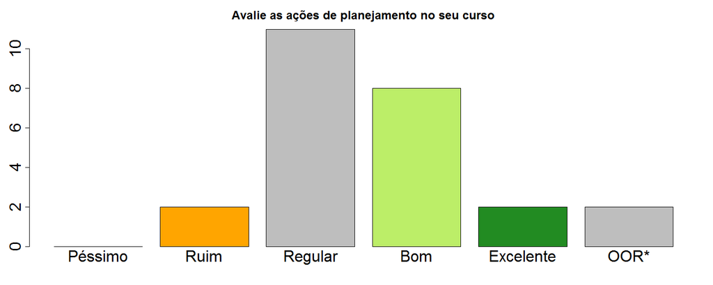

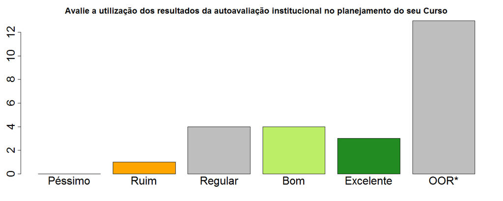

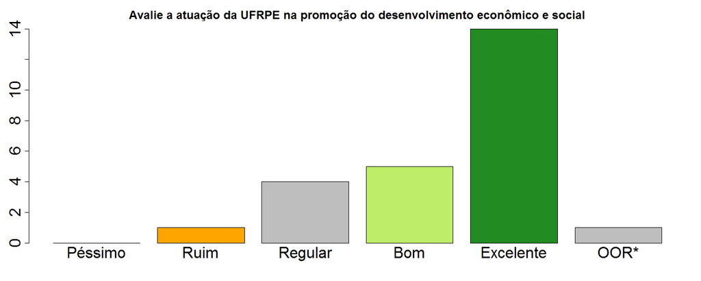

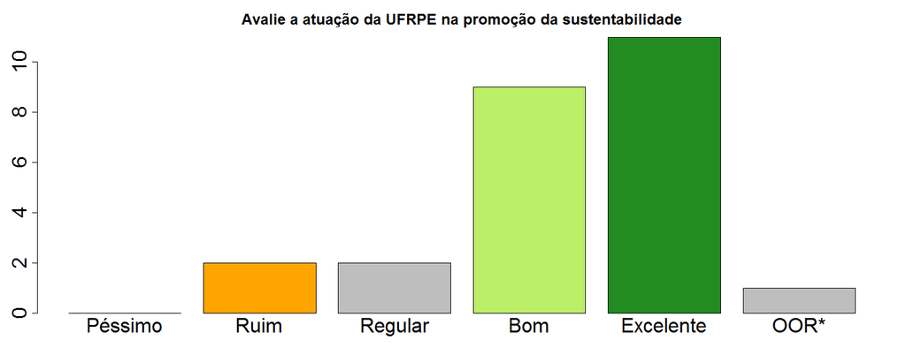

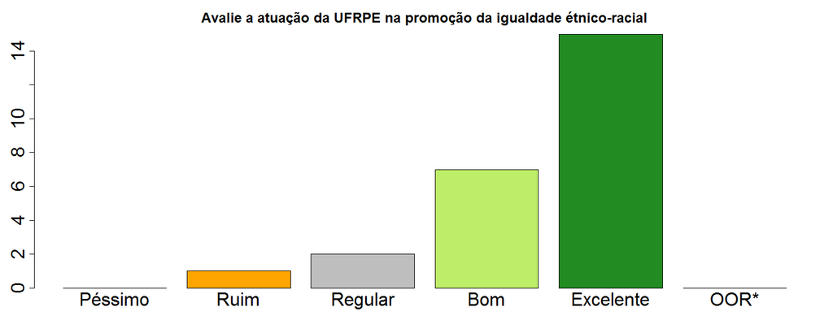

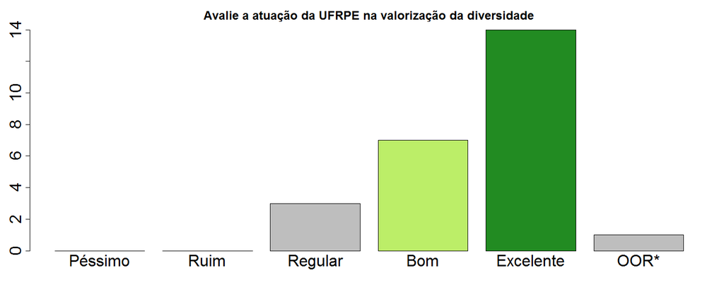

*OOR: Outras opções de resposta

# 6 Resultado completo (discentes)

| Média | Item | Péssimo (0) | Ruim (2.5) | Regular (5) | Bom (7.5) | Excelente (10) | OOR* |
| --- | --- | --- | --- | --- | --- | --- | --- |
| 8.7 | Avalie a atuação da UFRPE na promoção dos Direitos Humanos | 0 | 0 | 2 | 9 | 14 | 0 |
| 8.6 | Avalie a atuação da UFRPE na promoção da igualdade étnico-racial | 0 | 1 | 2 | 7 | 15 | 0 |
| 8.6 | Avalie a atuação da UFRPE na valorização da diversidade | 0 | 0 | 3 | 7 | 14 | 1 |
| 8.6 | Avalie o acesso a este questionário de autoavaliação da UFRPE | 0 | 1 | 1 | 9 | 14 | 0 |
| 8.3 | Avalie a atuação da UFRPE na promoção do desenvolvimento econômico e social | 0 | 1 | 4 | 5 | 14 | 1 |
| 8.2 | Avalie a atuação da UFRPE na gestão do patrimônio cultural | 0 | 0 | 4 | 9 | 10 | 2 |
| 8.1 | Avalie o acesso aos relatórios de autoavaliação da UFRPE | 0 | 0 | 3 | 12 | 9 | 1 |
| 8.0 | Avalie a atuação da UFRPE na promoção da sustentabilidade | 0 | 2 | 2 | 9 | 11 | 1 |
| 8.0 | Avalie o Plano de Desenvolvimento Institucional (PDI) da UFRPE como instrumento de gestão (Planejamento, execução e avaliação) | 0 | 0 | 3 | 7 | 6 | 9 |
| 7.8 | Avalie o Projeto de Autoavaliação Institucional adotado pela Comissão Própria de Avaliação (CPA) | 0 | 0 | 3 | 11 | 5 | 6 |
| 7.5 | Avalie o alinhamento das diretrizes e objetivos estratégicos do Plano de Desenvolvimento Institucional (PDI) com as ações executadas na UFRPE | 0 | 0 | 3 | 8 | 3 | 11 |
| 7.1 | Avalie a atuação da UFRPE na promoção da produção artística | 1 | 0 | 6 | 11 | 5 | 2 |
| 6.9 | Avalie a utilização dos resultados da autoavaliação institucional no planejamento do seu Curso | 0 | 1 | 4 | 4 | 3 | 13 |
| 6.9 | Avalie a visibilidade da Comissão Própria de Avaliação (CPA) nas Mídias Sociais (Facebook e Instagram) | 0 | 0 | 6 | 9 | 2 | 8 |
| 6.2 | Avalie o seu conhecimento sobre o Plano de Desenvolvimento Institucional | 0 | 3 | 4 | 9 | 1 | 8 |
| 6.1 | Avalie as ações de planejamento no seu curso | 0 | 2 | 11 | 8 | 2 | 2 |
| 6.0 | Avalie seu conhecimento sobre o Plano de Gestão de Logística Sustentável (PLS) da UFRPE | 0 | 2 | 8 | 7 | 1 | 7 |

*OOR: Outras opções de resposta